# ANOVA

### Introduction

In this lab, we will learn about Analysis of Variance (ANOVA). ANOVA is a type of linear model that can be used to compare the means of two or more groups to determine if there are any significant differences between them. It is an extension of the t-test, which can be used to compare the means of two groups.

ANOVA is used when we have categorical independent variables (also known as factors) and a continuous dependent variable. It helps us understand if the means of the dependent variable differ significantly across different levels of the independent variable.

### The Data

Suppose we are interested in studying the effectiveness of three different study techniques (A, B, and C) on student performance. We randomly assign 60 students to these three study techniques, with 20 students in each group. After a week of studying, we measure their test scores. The data are as follows:

```r
set.seed(1)

study_data <- data.frame(
  study_technique = rep(c("A", "B", "C"), each = 20),
  test_scores = rnorm(60, mean = c(30,  60, 85), sd = c(5))
)

kable(
study_data %>% head,
    "html") %>%
  kable_styling(font_size = 10,
                "striped") %>%
  scroll_box(width="100%")
```

| study_technique | test_scores |
| --- | --- |
| A | 26.86773 |
| A | 60.91822 |
| A | 80.82186 |
| A | 37.97640 |
| A | 61.64754 |
| A | 80.89766 |

### Setting up the hypothesis test

Setting up the Hypothesis Test To perform the ANOVA, we need to specify the null hypothesis and alternative hypothesis. The null hypothesis assumes that the means of all groups are equal, while the alternative hypothesis assumes that at least one group’s mean is different.

- Null hypothesis: The means of study techniques A, B, and C are equal.
- Alternative hypothesis: At least one study technique’s mean is different.

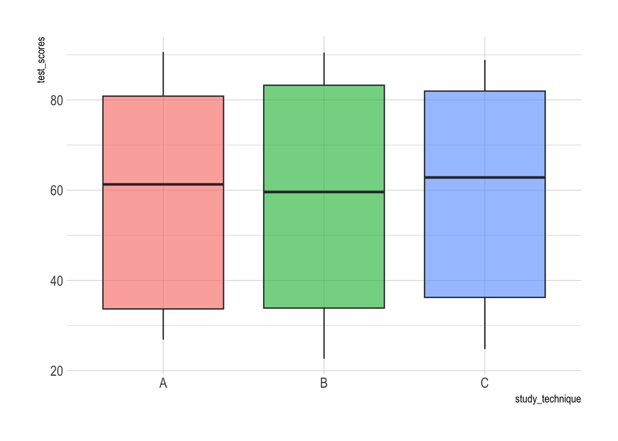

```r
study_data %>%
  ggplot(aes(x=study_technique,y=test_scores)) +
  geom_boxplot(aes(fill=study_technique), alpha=0.6) +
  theme_ipsum() +
  theme(
    legend.position = 'None'
  )
```

### Checking the Assumptions

Before conducting the ANOVA, we need to check the assumptions. The assumptions for ANOVA are:

- Independence: The observations within each group should be independent of each other.
- Normality: The data within each group should be approximately normally distributed.
- Homogeneity of variances (homoscedasticity): The variability (variance) of the data within each group should be approximately equal.

We can check the normality assumption by examining the histograms and normal probability plots for each group.

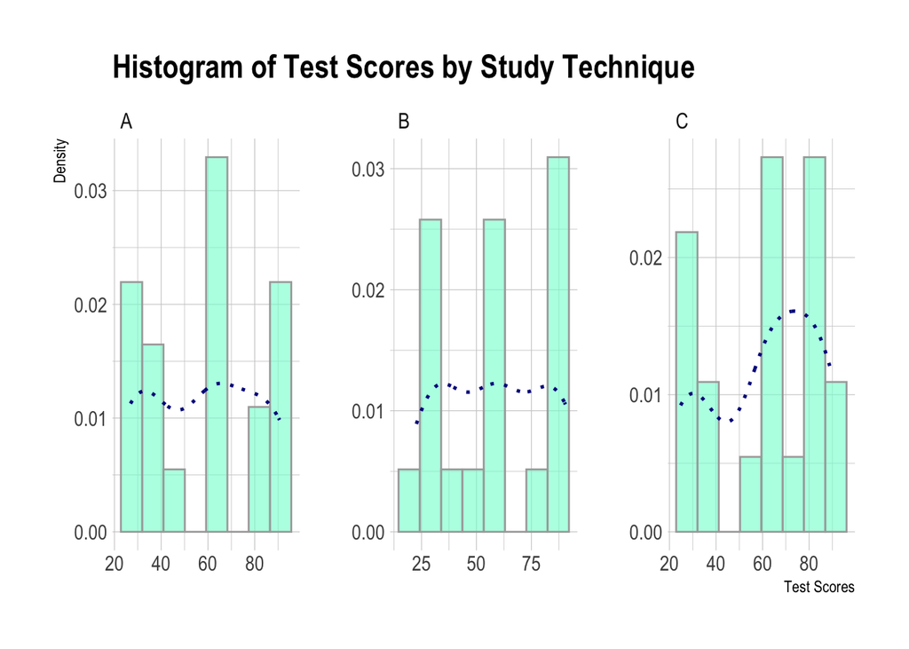

```r
ggplot(study_data, aes(x = test_scores)) +
  geom_histogram(aes(y = ..density..), bins = 8, color = "darkgrey", fill = "aquamarine", alpha=0.6) +
  geom_density(color = "darkblue", lwd = 0.9, linetype='dotted') +
  facet_wrap(~ study_technique, ncol = 3, scales = "free") +
  labs(title = "Histogram of Test Scores by Study Technique", x = "Test Scores", y = "Density") +
  theme_ipsum()
```

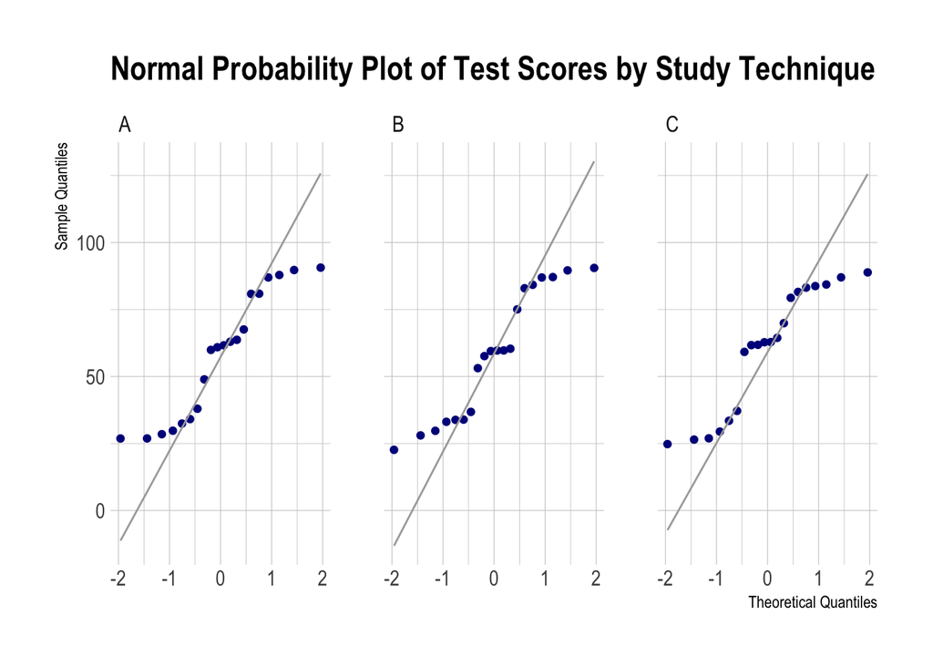

```r
ggplot(study_data, aes(sample = test_scores)) +
  stat_qq(color = "darkblue") +
  stat_qq_line(color = "darkgrey") +
  facet_wrap(~study_technique, ncol = 3) +
  labs(title = "Normal Probability Plot of Test Scores by Study Technique", x = "Theoretical Quantiles", y = "Sample Quantiles") +
  theme_ipsum()
```

To check the homogeneity of variances assumption, we can perform Levene’s test, which tests if the variances of the groups are equal.

```r
leveneTest(test_scores ~ study_technique, data = study_data)
```

```
## Levene's Test for Homogeneity of Variance (center = median)
##       Df F value Pr(>F)
## group  2  0.0662  0.936
##       57
```

The p-value for Levene’s test is greater than 0.05, indicating that we do not have enough evidence to reject the null hypothesis of equal variances. Therefore, we can assume the homogeneity of variances assumption holds.

### Performing ANOVA

```r
anova_result <- aov(test_scores ~ study_technique, data = study_data)
summary(anova_result)
```

```
##                 Df Sum Sq Mean Sq F value Pr(>F)
## study_technique  2     75    37.4   0.069  0.933
## Residuals       57  30734   539.2
```